# BLawrence_LiveSession11Assignment

Brandon Lawrence

November 11, 2016

## Live Session Unit 11 Assignment

Reference Data Set - data(visitors)

#### a) Plot the time series. Can you identify seasonal fluctuations and/or a trend?

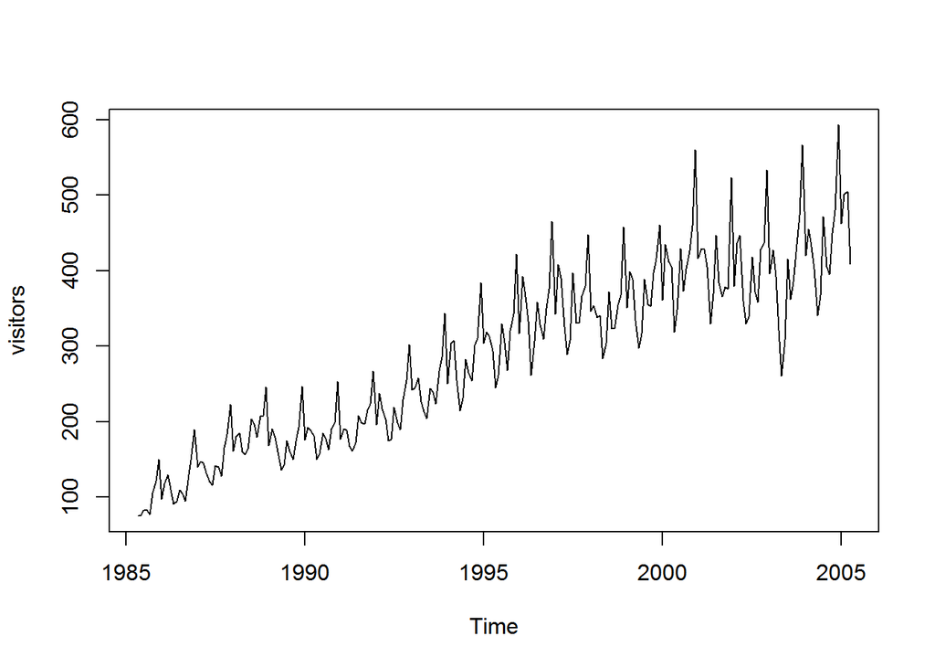

This data has an upward trend with a strong seasonal variation and increasing volatility.

#### b) Use a classical decomposition to calculate the trend-cycle and seasonal indices.

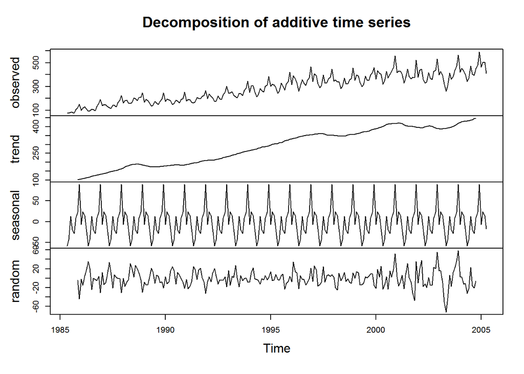

#### c) Do the results support the graphical interpretation from part (a)?

Yes, the trend is positive, the seasonal pattern is strong, and the random component become markedly more erratic over time.

#### d) Compute and plot the seasonally adjusted data.

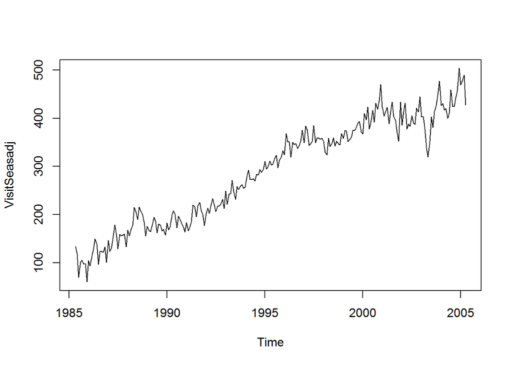

#### e) Change one observation to be an outlier (e.g., add 500 to one observation), and recompute the seasonally adjusted data. What is the effect of the outlier?

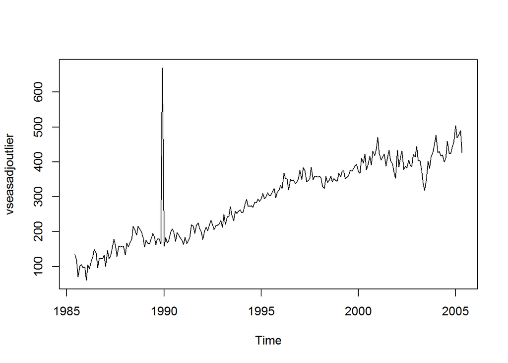

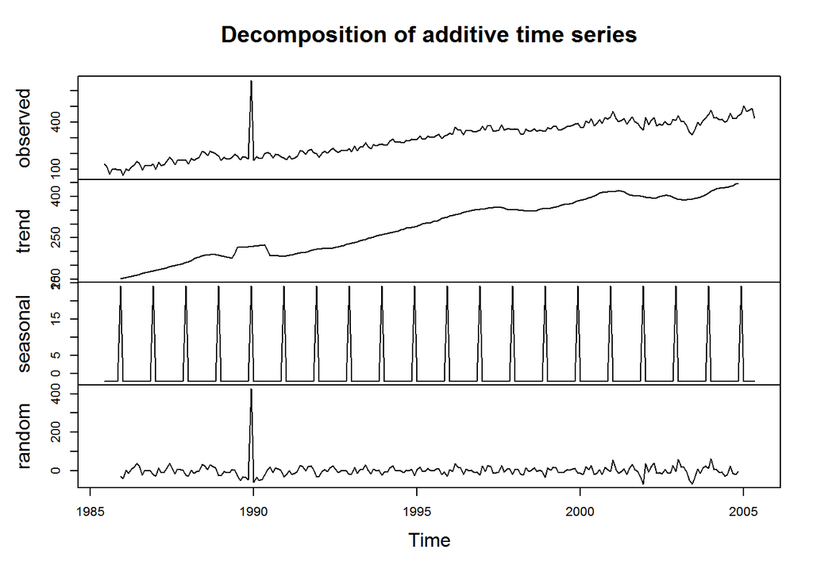

#### f) Does it make any difference if the outlier is near the end rather than in the middle of the time series?

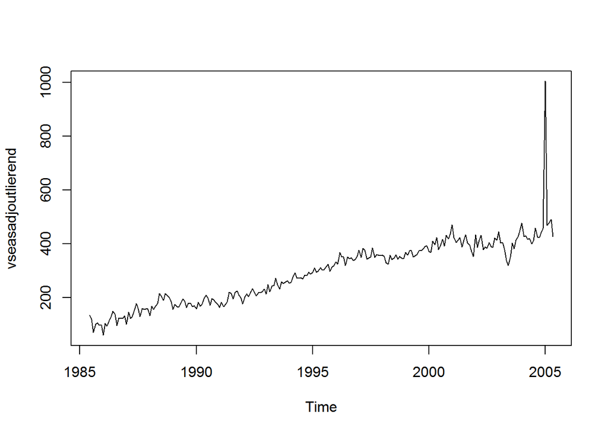

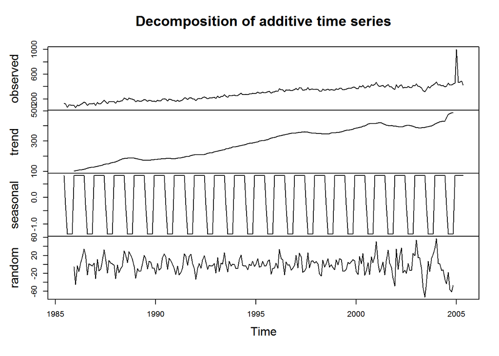

The decomposition weights the later outlier on the trend rather than random variation, presumably because there is not enough data to prove that the outlier is in fact an outlier and not a change to the trend.

#### g) Use STL to decompose the series.

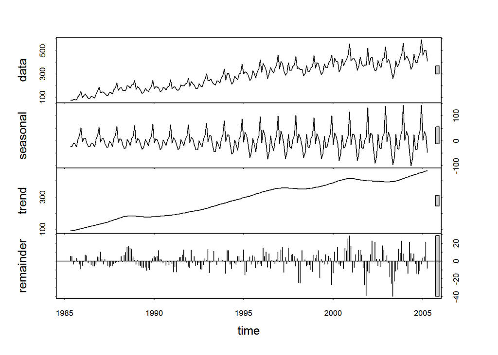